# Chapter 6: Analysis of longitudinal data

(3.12.-10.12.2019)

- **Data wrangling**

  R script of data Wrangling exercise is available here.

  https://github.com/yufanyin/IODS-project/blob/master/create_BPRS_rats_l.R
- **Reference to the data source**

  https://raw.githubusercontent.com/KimmoVehkalahti/MABS/master/Examples/data/BPRS.txt

  https://raw.githubusercontent.com/KimmoVehkalahti/MABS/master/Examples/data/rats.txt
- **Note:** 6.2-6.5 Analyses of chapter 8 of MABS using the RATS data (rats_l)

  6.6-6.8 Analyses of chapter 9 of MABS using the BPRS data (bprs_l)

## 6.1 Loading the wide and long data sets

Load and check the data sets

```r
# load necessary packages
library(tidyr)
library(dplyr)
library(corrplot)
library(ggplot2)
library(GGally)
library(knitr)
library(kableExtra)
library(ggthemes)
library(stringr)
library(lme4)
```

Load the wide (bprs & rats) and long (bprs_l & rats_l) data sets

```r
bprs <- read.table("G:/C-Open Data Science/0-191030/IODS-project-master/BPRS.txt", sep = " ", header = TRUE)
rats <- read.table("G:/C-Open Data Science/0-191030/IODS-project-master/rats.txt", header = TRUE)
bprs_l <- read.table("G:/C-Open Data Science/0-191030/IODS-project-master/BPRS_l.txt")
rats_l <- read.table("G:/C-Open Data Science/0-191030/IODS-project-master/rats_l.txt")
```

```r
str(bprs_l)
```

```
## 'data.frame':    360 obs. of  5 variables:
##  $ treatment: int  1 1 1 1 1 1 1 1 1 1 ...
##  $ subject  : int  1 2 3 4 5 6 7 8 9 10 ...
##  $ weeks    : Factor w/ 9 levels "week0","week1",..: 1 1 1 1 1 1 1 1 1 1 ...
##  $ BPRS     : int  42 58 54 55 72 48 71 30 41 57 ...
##  $ week     : int  0 0 0 0 0 0 0 0 0 0 ...
```

```r
str(rats_l)
```

```
## 'data.frame':    176 obs. of  5 variables:
##  $ ID    : int  1 2 3 4 5 6 7 8 9 10 ...
##  $ Group : int  1 1 1 1 1 1 1 1 2 2 ...
##  $ WD    : Factor w/ 11 levels "WD1","WD15","WD22",..: 1 1 1 1 1 1 1 1 1 1 ...
##  $ Weight: int  240 225 245 260 255 260 275 245 410 405 ...
##  $ Time  : int  1 1 1 1 1 1 1 1 1 1 ...
```

bprs data: factor treatment & subject rats data: factor ID & Group

```r
bprs_l$treatment <- factor(bprs_l$treatment)
bprs_l$subject <- factor(bprs_l$subject)
rats_l$ID <- factor(rats_l$ID)
rats_l$Group <- factor(rats_l$Group)
str(bprs_l)
```

```
## 'data.frame':    360 obs. of  5 variables:
##  $ treatment: Factor w/ 2 levels "1","2": 1 1 1 1 1 1 1 1 1 1 ...
##  $ subject  : Factor w/ 20 levels "1","2","3","4",..: 1 2 3 4 5 6 7 8 9 10 ...
##  $ weeks    : Factor w/ 9 levels "week0","week1",..: 1 1 1 1 1 1 1 1 1 1 ...
##  $ BPRS     : int  42 58 54 55 72 48 71 30 41 57 ...
##  $ week     : int  0 0 0 0 0 0 0 0 0 0 ...
```

```r
str(rats_l)
```

```
## 'data.frame':    176 obs. of  5 variables:
##  $ ID    : Factor w/ 16 levels "1","2","3","4",..: 1 2 3 4 5 6 7 8 9 10 ...
##  $ Group : Factor w/ 3 levels "1","2","3": 1 1 1 1 1 1 1 1 2 2 ...
##  $ WD    : Factor w/ 11 levels "WD1","WD15","WD22",..: 1 1 1 1 1 1 1 1 1 1 ...
##  $ Weight: int  240 225 245 260 255 260 275 245 410 405 ...
##  $ Time  : int  1 1 1 1 1 1 1 1 1 1 ...
```

The BPRS dataset

A total 40 male subjects were measured with 2 treatment groups using BPRS (Brief Psychiatric Rating Scale). One BPRS measurement was conducted before treatment started (week0), and weekly measurements followed up to 8 weeks. The BPRS assesses the levels of 18 symptom constructs to evaluate whether patients have schizophrenia (Vehkalahti & Everitt, 2019). The levels of symptoms constructs were from 1 (not present) to 7 (extremely severe).

The long BPRS data ‘bprs_l’

They consisted of 360 observations in 5 variables. The variables included:  
“treatment”: the psychological treatment of the male subjects (1 & 2)  
“subject”: the male individuals identification number “weeks”: the week of treatment and BPRS evaluation “bprs”: the values of bprs “week”: the week number of the BPRS evaluation.

```r
knitr::kable(bprs_l, caption = "The long BPRS data 'bprs_l'") %>%
  kable_styling(bootstrap_options = "striped", full_width = FALSE, position = "center") %>%
  scroll_box(height = "200px")
```

The long BPRS data ‘bprs_l’

| treatment | subject | weeks | BPRS | week |
| --- | --- | --- | --- | --- |
| 1 | 1 | week0 | 42 | 0 |
| 1 | 2 | week0 | 58 | 0 |
| 1 | 3 | week0 | 54 | 0 |
| 1 | 4 | week0 | 55 | 0 |
| 1 | 5 | week0 | 72 | 0 |
| 1 | 6 | week0 | 48 | 0 |
| 1 | 7 | week0 | 71 | 0 |
| 1 | 8 | week0 | 30 | 0 |
| 1 | 9 | week0 | 41 | 0 |
| 1 | 10 | week0 | 57 | 0 |
| 1 | 11 | week0 | 30 | 0 |
| 1 | 12 | week0 | 55 | 0 |
| 1 | 13 | week0 | 36 | 0 |
| 1 | 14 | week0 | 38 | 0 |
| 1 | 15 | week0 | 66 | 0 |
| 1 | 16 | week0 | 41 | 0 |
| 1 | 17 | week0 | 45 | 0 |
| 1 | 18 | week0 | 39 | 0 |
| 1 | 19 | week0 | 24 | 0 |
| 1 | 20 | week0 | 38 | 0 |
| 2 | 1 | week0 | 52 | 0 |
| 2 | 2 | week0 | 30 | 0 |
| 2 | 3 | week0 | 65 | 0 |
| 2 | 4 | week0 | 37 | 0 |
| 2 | 5 | week0 | 59 | 0 |
| 2 | 6 | week0 | 30 | 0 |
| 2 | 7 | week0 | 69 | 0 |
| 2 | 8 | week0 | 62 | 0 |
| 2 | 9 | week0 | 38 | 0 |
| 2 | 10 | week0 | 65 | 0 |

[output cut: 330 more lines]

The RATS dataset The data consisted of measurements on how rats grew. Three groups of rats got different diets. The body weight of every animal was measured over a period of 9 weeks. The research question is whether the growth profiles of the different diet groups differ (Vehkalahti & Everitt, 2019).

The long RATS data ‘rats_l’ The data consisted of 176 observations in 5 variables. The variables included:

“ID”: the individual rat’s identification number “Group”: the diet group (1, 2 & 3) “WD”: the factorial value of the time (the date when rat’ weight was measured) “Weight”: weight of individual rat at the given day “Time”: the time point of the weight measurement (days)

```r
# rats_ data set
knitr::kable(rats_l, caption = "The long RATS data 'rats_l'") %>%
  kable_styling(bootstrap_options = "striped", full_width = FALSE, position = "center") %>%
  scroll_box(height = "200px")
```

The long RATS data ‘rats_l’

| ID | Group | WD | Weight | Time |
| --- | --- | --- | --- | --- |
| 1 | 1 | WD1 | 240 | 1 |
| 2 | 1 | WD1 | 225 | 1 |
| 3 | 1 | WD1 | 245 | 1 |
| 4 | 1 | WD1 | 260 | 1 |
| 5 | 1 | WD1 | 255 | 1 |
| 6 | 1 | WD1 | 260 | 1 |
| 7 | 1 | WD1 | 275 | 1 |
| 8 | 1 | WD1 | 245 | 1 |
| 9 | 2 | WD1 | 410 | 1 |
| 10 | 2 | WD1 | 405 | 1 |
| 11 | 2 | WD1 | 445 | 1 |
| 12 | 2 | WD1 | 555 | 1 |
| 13 | 3 | WD1 | 470 | 1 |
| 14 | 3 | WD1 | 535 | 1 |
| 15 | 3 | WD1 | 520 | 1 |
| 16 | 3 | WD1 | 510 | 1 |
| 1 | 1 | WD8 | 250 | 8 |
| 2 | 1 | WD8 | 230 | 8 |
| 3 | 1 | WD8 | 250 | 8 |
| 4 | 1 | WD8 | 255 | 8 |
| 5 | 1 | WD8 | 260 | 8 |
| 6 | 1 | WD8 | 265 | 8 |
| 7 | 1 | WD8 | 275 | 8 |
| 8 | 1 | WD8 | 255 | 8 |
| 9 | 2 | WD8 | 415 | 8 |
| 10 | 2 | WD8 | 420 | 8 |
| 11 | 2 | WD8 | 445 | 8 |
| 12 | 2 | WD8 | 560 | 8 |
| 13 | 3 | WD8 | 465 | 8 |
| 14 | 3 | WD8 | 525 | 8 |

[output cut: 146 more lines]

## Part 1 Analyses of chapter 8 of MABS using the RATS data (rats_l)

**6.2-6.5**

## 6.2 Standardizing the dataset and exploring the data graphically

### 6.2.1 Exploring the data graphically

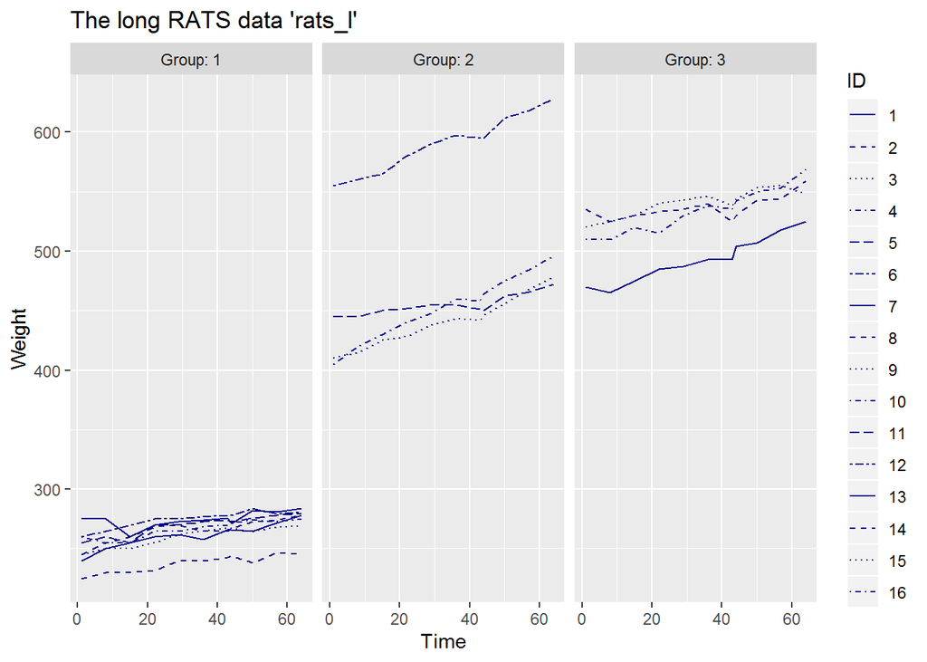

```r
ggplot(rats_l, aes(x = Time, y = Weight,linetype = ID)) +
  geom_line(color = "darkblue") +
  scale_linetype_manual(values = rep(1:6, times= 3)) +
  facet_grid(. ~ Group, labeller = label_both) +
  theme(legend.position = "right") +
  scale_y_continuous(limits = c(min(rats_l$Weight), max(rats_l$Weight))) +
 ggtitle("The long RATS data 'rats_l'")
```

Rat’s starting weights in group 2 & 3 were higher than in group 1 and the weights in group 2 & 3 increased in quite high rates. The weights in group 1 increased in a smaller rate.

### 6.2.2 Standardizing the dataset

Calculating StdWeight and added as a new variable to the ‘rats_l’

```r
rats_l <- rats_l %>%
  group_by(Time) %>%
  mutate(StdWeight = ((Weight - mean(Weight))/sd(Weight))) %>%
  ungroup()
str(rats_l)
```

```
## Classes 'tbl_df', 'tbl' and 'data.frame':    176 obs. of  6 variables:
##  $ ID       : Factor w/ 16 levels "1","2","3","4",..: 1 2 3 4 5 6 7 8 9 10 ...
##  $ Group    : Factor w/ 3 levels "1","2","3": 1 1 1 1 1 1 1 1 2 2 ...
##  $ WD       : Factor w/ 11 levels "WD1","WD15","WD22",..: 1 1 1 1 1 1 1 1 1 1 ...
##  $ Weight   : int  240 225 245 260 255 260 275 245 410 405 ...
##  $ Time     : int  1 1 1 1 1 1 1 1 1 1 ...
##  $ StdWeight: num  -1.001 -1.12 -0.961 -0.842 -0.882 ...
```

### 6.2.3 Plotting the standardised data

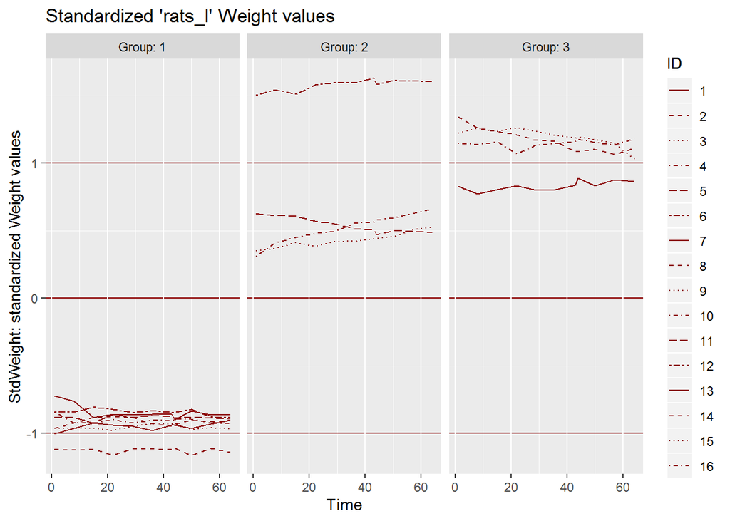

```r
ggplot(rats_l, aes(x = Time, y = StdWeight, linetype = ID)) +
  geom_line(color = "darkred") +
  scale_linetype_manual(values = rep(1:6, times=3)) +
  facet_grid(. ~ Group, labeller = label_both) +
  scale_y_continuous(name = "StdWeight: standardized Weight values") +
  ggtitle("Standardized 'rats_l' Weight values") +
  theme(panel.grid.major.y = element_line(colour = "darkred"))
```

## 6.3 Profiles

### 6.3.1 Adding categorical variable

Add the Time as a categorical variable “Time1”

```r
rats_l <- rats_l %>%
  mutate(Time1 = factor(rats_l$Time)) %>%
  ungroup()
str(rats_l)
```

```
## Classes 'tbl_df', 'tbl' and 'data.frame':    176 obs. of  7 variables:
##  $ ID       : Factor w/ 16 levels "1","2","3","4",..: 1 2 3 4 5 6 7 8 9 10 ...
##  $ Group    : Factor w/ 3 levels "1","2","3": 1 1 1 1 1 1 1 1 2 2 ...
##  $ WD       : Factor w/ 11 levels "WD1","WD15","WD22",..: 1 1 1 1 1 1 1 1 1 1 ...
##  $ Weight   : int  240 225 245 260 255 260 275 245 410 405 ...
##  $ Time     : int  1 1 1 1 1 1 1 1 1 1 ...
##  $ StdWeight: num  -1.001 -1.12 -0.961 -0.842 -0.882 ...
##  $ Time1    : Factor w/ 11 levels "1","8","15","22",..: 1 1 1 1 1 1 1 1 1 1 ...
```

### 6.3.2 Boxplot

The overview of rats’ weights over the whole measurement period with boxplots. Different diet groups were in different colors.

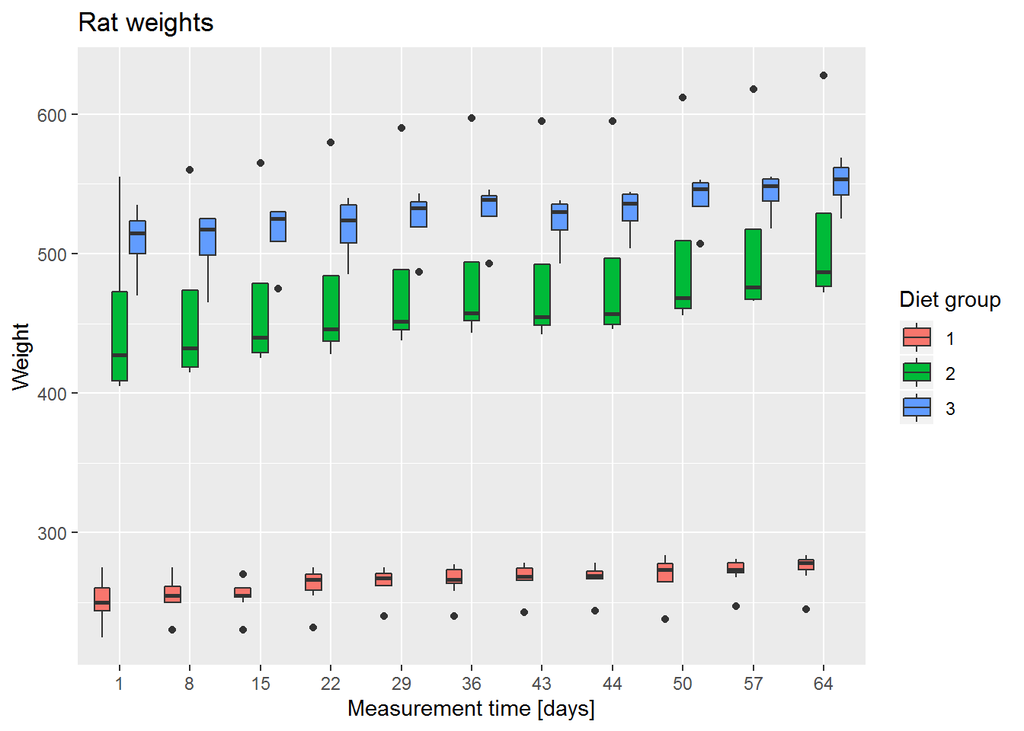

```r
ggplot(data = rats_l, aes(x = rats_l$Time1, y = Weight, fill = rats_l$Group)) +
  geom_boxplot() +
  ylab("Weight") +
  xlab("Measurement time [days]") +
  ggtitle("Rat weights") +
  scale_fill_discrete(name = "Diet group") +
  theme(legend.position = "right")
```

Calculate mean weight of all rats & the standard error of each diet group and add as a variable

```r
n_rats <- rats_l$Time %>% unique() %>% length()
rats_s <- rats_l %>%
  group_by(Group, Time) %>%
  summarise(mean = mean(Weight), se = (sd(Weight)/sqrt(n_rats))) %>%
  ungroup()
str(rats_s)
```

```
## Classes 'tbl_df', 'tbl' and 'data.frame':    33 obs. of  4 variables:
##  $ Group: Factor w/ 3 levels "1","2","3": 1 1 1 1 1 1 1 1 1 1 ...
##  $ Time : int  1 8 15 22 29 36 43 44 50 57 ...
##  $ mean : num  251 255 254 262 265 ...
##  $ se   : num  4.59 3.95 3.46 4.1 3.33 ...
```

### 6.3.3 Plotting the mean profiles

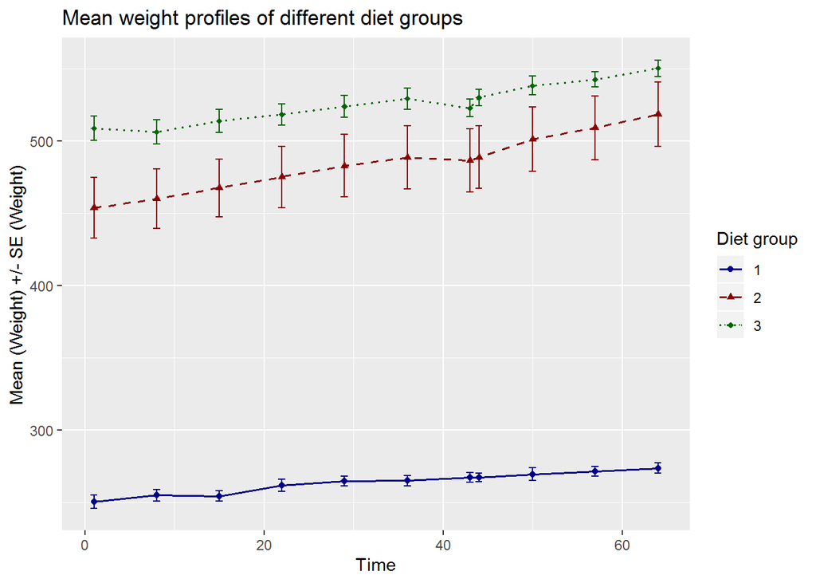

```r
ggplot(rats_s, aes(x = Time, y = mean, linetype = Group,  color = Group, shape = Group)) +
  geom_line(size = 0.6) +
  scale_linetype_manual(name = "Diet group", values = c(1,2,3)) +
  geom_point(size=1.5) +
  scale_shape_manual(name = "Diet group", values = c(16,17,18)) +
  scale_color_manual(name = "Diet group", values = c("darkblue", "darkred", "darkgreen")) +
  geom_errorbar(aes(ymin=mean-se, ymax=mean+se, linetype="1"), width=0.8) +
  theme(legend.position = "right") +
  scale_y_continuous(name = "Mean (Weight) +/- SE (Weight)") +
  ggtitle("Mean weight profiles of different diet groups")
```

## 6.4 Finding the outlier

### 6.4.1 Creating summary variable and calculating the mean weights of every group

Create a summary data by Group and ID with mean as the summary variable

```r
rats_l10s <- rats_l %>%
  filter(Time > 1) %>%
  group_by(Group, ID) %>%
  summarise(mean=mean(Weight)) %>%
  ungroup()
str(rats_l10s)
```

```
## Classes 'tbl_df', 'tbl' and 'data.frame':    16 obs. of  3 variables:
##  $ Group: Factor w/ 3 levels "1","2","3": 1 1 1 1 1 1 1 1 2 2 ...
##  $ ID   : Factor w/ 16 levels "1","2","3","4",..: 1 2 3 4 5 6 7 8 9 10 ...
##  $ mean : num  263 239 262 267 271 ...
```

### 6.4.2 Boxplot of mean weights of different diet groups excluding the first measurement

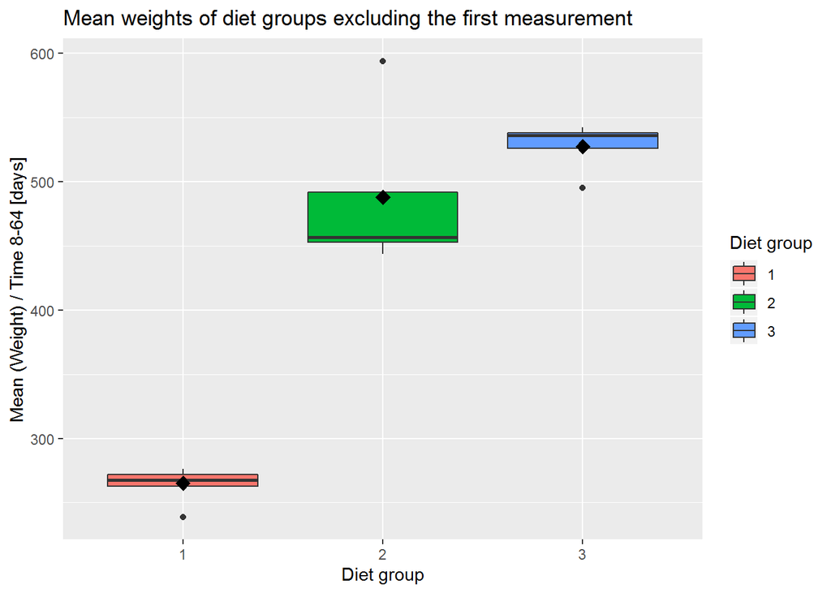

```r
ggplot(rats_l10s, aes(x = Group, y = mean, fill = Group)) +
  geom_boxplot() +
  stat_summary(fun.y = "mean", geom = "point", shape = 23, size = 3, fill = "black") +
  scale_y_continuous(name = "Mean (Weight) / Time 8-64 [days]") +
  xlab("Diet group") +
  scale_fill_discrete(name = "Diet group") +
  ggtitle("Mean weights of diet groups excluding the first measurement")
```

The boxplot showed the outliers and they could disturb further comparisons of the different diet groups.

### 6.4.3 Removing outlier

```r
rats_l10s_o <- rats_l10s %>%
    filter(
      (mean > 250 & Group == 1) |
      (mean < 550 & Group == 2) |
      (mean > 500 & Group == 3))  %>%
      ungroup()
str(rats_l10s_o)
```

```
## Classes 'tbl_df', 'tbl' and 'data.frame':    13 obs. of  3 variables:
##  $ Group: Factor w/ 3 levels "1","2","3": 1 1 1 1 1 1 1 2 2 2 ...
##  $ ID   : Factor w/ 16 levels "1","2","3","4",..: 1 3 4 5 6 7 8 9 10 11 ...
##  $ mean : num  263 262 267 271 276 ...
```

### 6.4.Boxplot of the mean value without the outlier

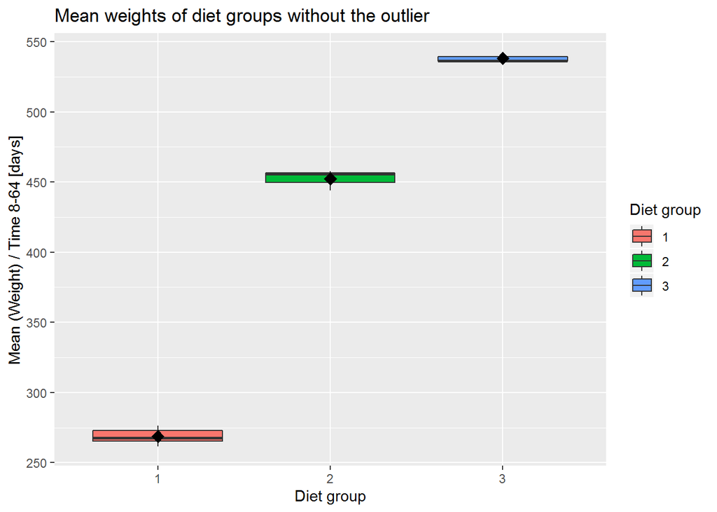

```r
ggplot(rats_l10s_o, aes(x = Group, y = mean, fill = Group)) +
  geom_boxplot() +
  stat_summary(fun.y = "mean", geom = "point", shape = 23, size = 3, fill = "black") +
  scale_y_continuous(name = "Mean (Weight) / Time 8-64 [days]") +
  xlab("Diet group") +
  scale_fill_discrete(name = "Diet group") +
  ggtitle("Mean weights of diet groups without the outlier")
```

This time there were no outlier values in the boxplot Mean weights of diet groups during 8 to 64 days.

## 6.5 Linear regression model and ANOVA

**Note:** I used ANOVA more frequently than t-test so I skip t-test.

Creating a new data table rats_l10s_b. The weight baseline values were created by the first weigh measurement on day 1 (WD1) as a new variable to the summary data.

```r
rats_l10s_b <- rats_l10s %>%
  mutate(baseline = rats$WD1)
rats_l10s_b %>% knitr::kable() %>% kable_styling(bootstrap_options = "striped", full_width = FALSE, position = "center") %>% scroll_box(height = "200px")
```

| Group | ID | mean | baseline |
| --- | --- | --- | --- |
| 1 | 1 | 263.2 | 240 |
| 1 | 2 | 238.9 | 225 |
| 1 | 3 | 261.7 | 245 |
| 1 | 4 | 267.2 | 260 |
| 1 | 5 | 270.9 | 255 |
| 1 | 6 | 276.2 | 260 |
| 1 | 7 | 274.6 | 275 |
| 1 | 8 | 267.5 | 245 |
| 2 | 9 | 443.9 | 410 |
| 2 | 10 | 457.5 | 405 |
| 2 | 11 | 455.8 | 445 |
| 2 | 12 | 594.0 | 555 |
| 3 | 13 | 495.2 | 470 |
| 3 | 14 | 536.4 | 535 |
| 3 | 15 | 542.2 | 520 |
| 3 | 16 | 536.2 | 510 |

To find which diet group had the highest increase in weight during the measurement period, anova tests were done using this new data ‘rats_l10s_b’ with the mean weight values and the baseline weight values.

### 6.5.1 Linear regression model 1 (mean weight ~ diet groups)

```r
rats_lrm1 <- lm(mean ~ Group, data = rats_l10s_b)
round(rats_lrm1$coefficients, digits = 2) %>% knitr::kable() %>% kable_styling(bootstrap_options = "striped", full_width = FALSE, position = "center")
```

|  | x |
| --- | --- |
| (Intercept) | 265.02 |
| Group2 | 222.77 |
| Group3 | 262.48 |

The model showed that the mean value of group 2 was 222g higher and the mean value of group 3 was 262g higher than that of group 1.

Examine the group means using a post-hoc test after the ANOVA to find whether the diet groups differed to each other.

The model shows that the mean value of group 2 is 222g higher and the mean value of group 3 is 262g higher compared to group 1 mean weights. Let’s have a look now if the diet groups differ to each other. With a post-hoc test after the ANOVA we can check the group means.

### 6.5.2 ANOVA of Linear regression model 1 (mean weight ~ diet groups)

```r
rats_anova1 <- anova(rats_lrm1)
rats_anova1
```

```
## Analysis of Variance Table
##
## Response: mean
##           Df Sum Sq Mean Sq F value    Pr(>F)
## Group      2 238620  119310  88.525 2.679e-08 ***
## Residuals 13  17521    1348
## ---
## Signif. codes:  0 '***' 0.001 '**' 0.01 '*' 0.05 '.' 0.1 ' ' 1
```

### 6.5.3 ANOVA with a post-hoc test

Perform an ANOVA and a post-hoc test (TukeyHSD) to find whether group means of diet groups were different from each other. The dataset `rats_l10s_b` was without the first measurement (start value) and inluded the outlier values.

```r
rats_anova2 <- aov(mean ~ Group, data = rats_l10s_b)
summary(rats_anova2)
```

```
##             Df Sum Sq Mean Sq F value   Pr(>F)
## Group        2 238620  119310   88.53 2.68e-08 ***
## Residuals   13  17521    1348
## ---
## Signif. codes:  0 '***' 0.001 '**' 0.01 '*' 0.05 '.' 0.1 ' ' 1
```

```r
TukeyHSD(rats_anova2, "Group", ordered = TRUE, conf.level = 0.95)
```

```
##   Tukey multiple comparisons of means
##     95% family-wise confidence level
##     factor levels have been ordered
##
## Fit: aov(formula = mean ~ Group, data = rats_l10s_b)
##
## $Group
##        diff       lwr      upr     p adj
## 2-1 222.775 163.41452 282.1355 0.0000006
## 3-1 262.475 203.11452 321.8355 0.0000001
## 3-2  39.700 -28.84358 108.2436 0.3099506
```

This post-hoc test provided the differences between the diet groups. Group 1 & 2 were significantly different in mean weight. So were Group 1 & 3. Group 2 and 3 were not significantly different in the mean weight mean, influenced by the outlier.

### 6.5.4 Linear regression model 2 (mean ~ baseline + Group)

The difference of each group to the baselines:

The linear model with the mean as the response

```r
rats_lrm2 <- lm(mean ~ baseline + Group, data = rats_l10s_b)
round(rats_lrm2$coefficients, digits = 2) %>% knitr::kable() %>% kable_styling(bootstrap_options = "striped", full_width = FALSE, position = "center")
```

|  | x |
| --- | --- |
| (Intercept) | 33.16 |
| baseline | 0.93 |
| Group2 | 34.86 |
| Group3 | 23.68 |

### 6.5.5 ANOVA of Linear regression model 2 (mean ~ baseline + Group)

```r
rats_anova3 <- anova(rats_lrm2)
rats_anova3
```

```
## Analysis of Variance Table
##
## Response: mean
##           Df Sum Sq Mean Sq   F value   Pr(>F)
## baseline   1 253625  253625 1859.8201 1.57e-14 ***
## Group      2    879     439    3.2219  0.07586 .
## Residuals 12   1636     136
## ---
## Signif. codes:  0 '***' 0.001 '**' 0.01 '*' 0.05 '.' 0.1 ' ' 1
```

## Part 2 Analyses of chapter 9 of MABS using the BPRS data (bprs_l)

**6.6-6.8**

(10.12.2019)

### Overview plot

```r
str(bprs_l)
```

```
## 'data.frame':    360 obs. of  5 variables:
##  $ treatment: Factor w/ 2 levels "1","2": 1 1 1 1 1 1 1 1 1 1 ...
##  $ subject  : Factor w/ 20 levels "1","2","3","4",..: 1 2 3 4 5 6 7 8 9 10 ...
##  $ weeks    : Factor w/ 9 levels "week0","week1",..: 1 1 1 1 1 1 1 1 1 1 ...
##  $ BPRS     : int  42 58 54 55 72 48 71 30 41 57 ...
##  $ week     : int  0 0 0 0 0 0 0 0 0 0 ...
```

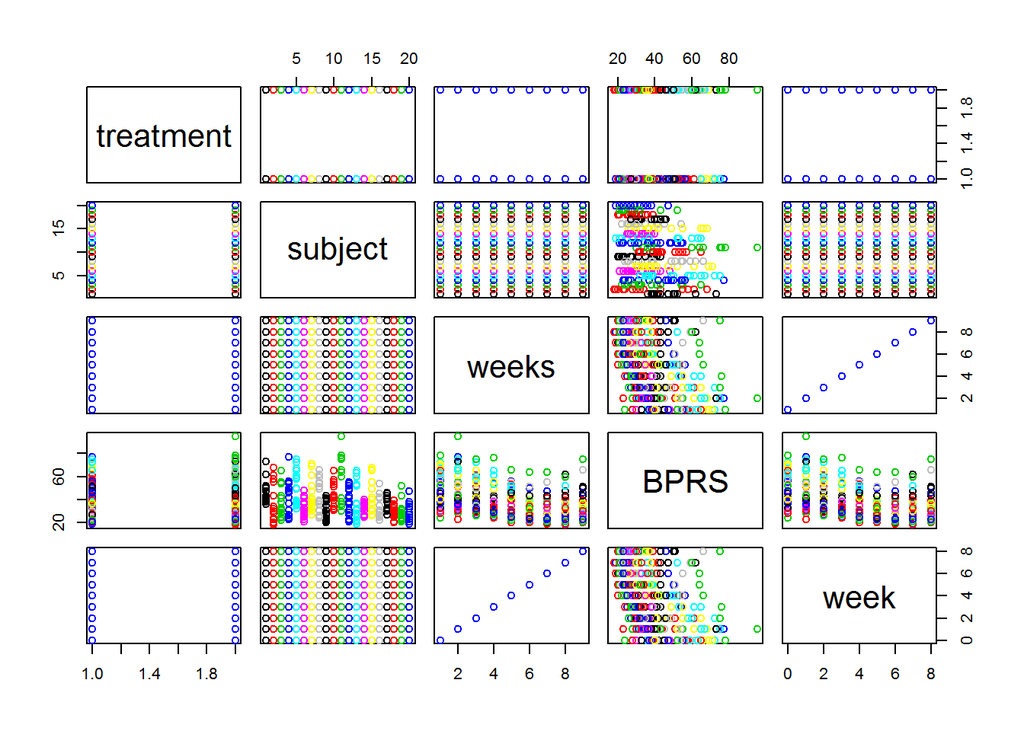

```r
pairs(bprs_l, col = bprs_l$subject)
```

Plotting the bprs_l

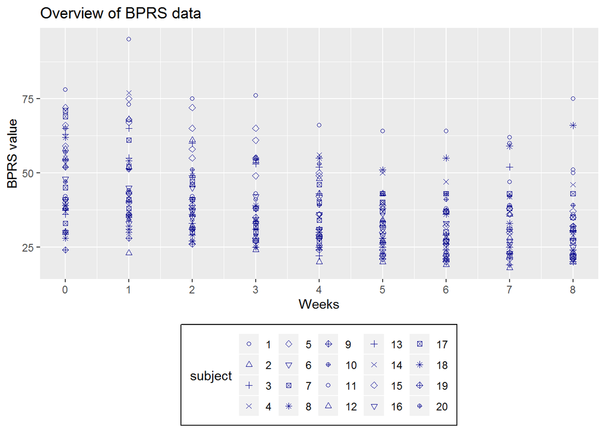

```r
ggplot(bprs_l, aes(x = week, y = BPRS, shape = subject, group = treatment)) +
  geom_point(color = "darkblue") +
  scale_shape_manual(values = rep(1:10, times = 2)) +
  scale_x_continuous(name = "Weeks", breaks = seq(0,8,1)) +
  scale_y_continuous(name = "BPRS value") +
  theme(legend.position = "bottom") +
  ggtitle("Overview of BPRS data") +
  theme(legend.box.background = element_rect(),legend.box.margin = margin(2, 2, 2, 2))
```

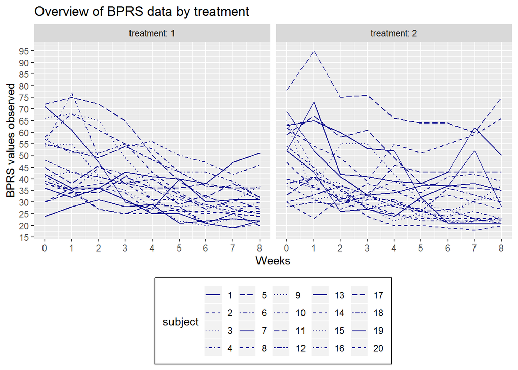

```r
ggplot(bprs_l, aes(x = week, y = BPRS, linetype = subject)) +
  geom_line(color = "darkblue") +
  scale_linetype_manual(values = rep(1:6, times = 4)) +
  facet_grid(. ~ treatment, labeller = label_both) +
  scale_x_continuous(name = "Weeks", breaks = seq(0,8,1)) +
  scale_y_continuous(name = "BPRS values observed", breaks = seq(10,100,5)) +
  theme(legend.position = "bottom") +
  ggtitle("Overview of BPRS data by treatment") +
  theme(legend.box.background = element_rect(),legend.box.margin = margin(2, 2, 2, 2))
```

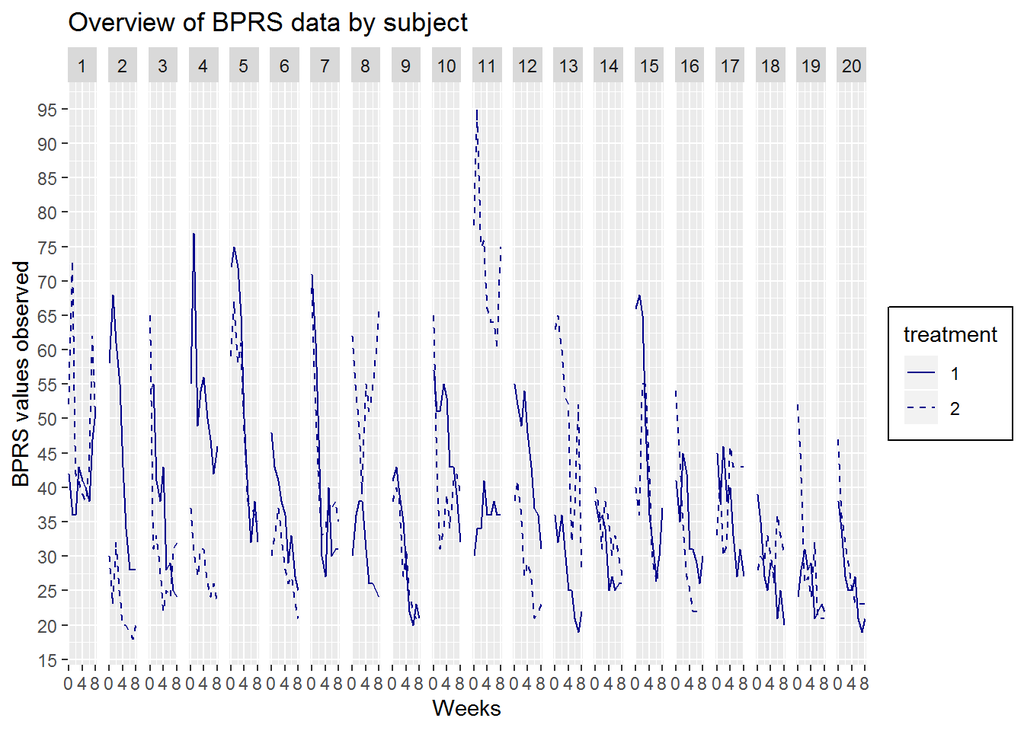

```r
ggplot(bprs_l, aes(x = week, y = BPRS)) +
  geom_line(aes(linetype = treatment), color = "darkblue") +
  scale_linetype_manual(values = rep(1:2, times = 1)) +
  facet_grid(.~ subject) +
  scale_x_continuous(name = "Weeks", breaks = seq(0,8,4)) +
  scale_y_continuous(name = "BPRS values observed", breaks = seq(10,100,5)) +
  theme(legend.position = "right") +
  ggtitle("Overview of BPRS data by subject") +
  theme(legend.box.background = element_rect(),legend.box.margin = margin(2, 2, 2, 2))
```

There were 40 subjects in 2 treatment groups (20 in each group). After the first BPRS determination (week 0), the treatment started and 8 more BPRS determinations followed.

### Linear model 1 (BPRS ~ week + treatment)

In the first linear regression model, the BPRS value was dependent varibale and week + treatment were independent variables (explanatory variables).

```r
bprs_l_lrm1 <- lm(BPRS ~ week + treatment, data = bprs_l)
summary(bprs_l_lrm1)
```

```
##
## Call:
## lm(formula = BPRS ~ week + treatment, data = bprs_l)
##
## Residuals:
##     Min      1Q  Median      3Q     Max
## -22.454  -8.965  -3.196   7.002  50.244
##
## Coefficients:
##             Estimate Std. Error t value Pr(>|t|)
## (Intercept)  46.4539     1.3670  33.982   <2e-16 ***
## week         -2.2704     0.2524  -8.995   <2e-16 ***
## treatment2    0.5722     1.3034   0.439    0.661
## ---
## Signif. codes:  0 '***' 0.001 '**' 0.01 '*' 0.05 '.' 0.1 ' ' 1
##
## Residual standard error: 12.37 on 357 degrees of freedom
## Multiple R-squared:  0.1851, Adjusted R-squared:  0.1806
## F-statistic: 40.55 on 2 and 357 DF,  p-value: < 2.2e-16
```

To explore whether treatments helped patients and whether the subjects (patients) affected the model, the subjects were added as a random effect term to a random intercept model.

## 6.6 Random intercept model (BPRS ~ week + treatment + (1 | subject))

In the random intercept model, “treatment” and the measurement periods “week” were the explanatory variables. The subjects (the 40 men which undergoing the treatment and measurements) was the random-effects term. This model explored whether linear regression fitted for each subject to the other subjects.

```r
bprs_l_rim <- lmer(BPRS ~ week + treatment + (1 | subject), data = bprs_l, REML = FALSE)
summary(bprs_l_rim)
```

```
## Linear mixed model fit by maximum likelihood  ['lmerMod']
## Formula: BPRS ~ week + treatment + (1 | subject)
##    Data: bprs_l
##
##      AIC      BIC   logLik deviance df.resid
##   2748.7   2768.1  -1369.4   2738.7      355
##
## Scaled residuals:
##     Min      1Q  Median      3Q     Max
## -3.0481 -0.6749 -0.1361  0.4813  3.4855
##
## Random effects:
##  Groups   Name        Variance Std.Dev.
##  subject  (Intercept)  47.41    6.885
##  Residual             104.21   10.208
## Number of obs: 360, groups:  subject, 20
##
## Fixed effects:
##             Estimate Std. Error t value
## (Intercept)  46.4539     1.9090  24.334
## week         -2.2704     0.2084 -10.896
## treatment2    0.5722     1.0761   0.532
##
## Correlation of Fixed Effects:
##            (Intr) week
## week       -0.437
## treatment2 -0.282  0.000
```

According to the summary, the standard error of the measurement periods ‘week’ in the random intercept model (0.2084) was smaller than the standard error in the linear regression model (0.2524). Similarly, the standard error of the treatment 2 in the random intercept model (1.0761) was smaller than that in the linear regression model (1.3034). They meant that the effect of subjects was taken into account in this model.

Generally, the mixed model takes into account the correlations between the observations (‘subjects’). So it can be more accurate than linear regression model. The p-value was calculated by inverse function of the t-values (inverting the t value to the p value).

## 6.7 Random Intercept and Random Slope Model (BPRS ~ week + treatment + (week | subject))

Fit a random intercept and random slope model to the BPRS values. It allowed the linear regression to fit for every patient (‘subject’) to differ in the intercept and in the slope. ‘Subject’ differences was taken into account of the BPRS values and the measurement period. In this model, “week” and “subject” were random-effect terms.

A total of 9 (0-8 weeks) different regression models were defined for every subject for every time period (every week).

```r
bprs_l_rim1 <- lmer(BPRS ~ week + treatment + (week | subject), data = bprs_l, REML = FALSE)
summary(bprs_l_rim1)
```

```
## Linear mixed model fit by maximum likelihood  ['lmerMod']
## Formula: BPRS ~ week + treatment + (week | subject)
##    Data: bprs_l
##
##      AIC      BIC   logLik deviance df.resid
##   2745.4   2772.6  -1365.7   2731.4      353
##
## Scaled residuals:
##     Min      1Q  Median      3Q     Max
## -2.8919 -0.6194 -0.0691  0.5531  3.7977
##
## Random effects:
##  Groups   Name        Variance Std.Dev. Corr
##  subject  (Intercept) 64.8222  8.0512
##           week         0.9609  0.9803   -0.51
##  Residual             97.4304  9.8707
## Number of obs: 360, groups:  subject, 20
##
## Fixed effects:
##             Estimate Std. Error t value
## (Intercept)  46.4539     2.1052  22.066
## week         -2.2704     0.2977  -7.626
## treatment2    0.5722     1.0405   0.550
##
## Correlation of Fixed Effects:
##            (Intr) week
## week       -0.582
## treatment2 -0.247  0.000
```

The results of this model showed not much difference with the model above. ANOVA was conducted to find differences in these models.

```r
anova(bprs_l_rim1, bprs_l_rim)
```

```
## Data: bprs_l
## Models:
## bprs_l_rim: BPRS ~ week + treatment + (1 | subject)
## bprs_l_rim1: BPRS ~ week + treatment + (week | subject)
##             Df    AIC    BIC  logLik deviance  Chisq Chi Df Pr(>Chisq)
## bprs_l_rim   5 2748.7 2768.1 -1369.4   2738.7
## bprs_l_rim1  7 2745.4 2772.6 -1365.7   2731.4 7.2721      2    0.02636 *
## ---
## Signif. codes:  0 '***' 0.001 '**' 0.01 '*' 0.05 '.' 0.1 ' ' 1
```

The ANOVA showed that the random Intercept and random Slope model (taking week and subject into account) gave a better fit for the data (p-value of 0.02) with a significant outcome.

## 6.8 Random intercept and random slope model with interaction (BPRS ~ week * treatment + (week | subject))

In the following random intercept and random slope model, the interaction of treatment and time (weeks) were included to see whether the treatment time period interacted with the BRPS value outcome.

```r
bprs_l_rim2 <- lmer(BPRS ~ week * treatment + (week | subject), data = bprs_l, REML = FALSE)
summary(bprs_l_rim2)
```

```
## Linear mixed model fit by maximum likelihood  ['lmerMod']
## Formula: BPRS ~ week * treatment + (week | subject)
##    Data: bprs_l
##
##      AIC      BIC   logLik deviance df.resid
##   2744.3   2775.4  -1364.1   2728.3      352
##
## Scaled residuals:
##     Min      1Q  Median      3Q     Max
## -3.0512 -0.6271 -0.0768  0.5288  3.9260
##
## Random effects:
##  Groups   Name        Variance Std.Dev. Corr
##  subject  (Intercept) 64.9964  8.0620
##           week         0.9687  0.9842   -0.51
##  Residual             96.4707  9.8220
## Number of obs: 360, groups:  subject, 20
##
## Fixed effects:
##                 Estimate Std. Error t value
## (Intercept)      47.8856     2.2521  21.262
## week             -2.6283     0.3589  -7.323
## treatment2       -2.2911     1.9090  -1.200
## week:treatment2   0.7158     0.4010   1.785
##
## Correlation of Fixed Effects:
##             (Intr) week   trtmn2
## week        -0.650
## treatment2  -0.424  0.469
## wek:trtmnt2  0.356 -0.559 -0.840
```

```r
anova(bprs_l_rim2, bprs_l_rim1)
```

```
## Data: bprs_l
## Models:
## bprs_l_rim1: BPRS ~ week + treatment + (week | subject)
## bprs_l_rim2: BPRS ~ week * treatment + (week | subject)
##             Df    AIC    BIC  logLik deviance  Chisq Chi Df Pr(>Chisq)
## bprs_l_rim1  7 2745.4 2772.6 -1365.7   2731.4
## bprs_l_rim2  8 2744.3 2775.4 -1364.1   2728.3 3.1712      1    0.07495 .
## ---
## Signif. codes:  0 '***' 0.001 '**' 0.01 '*' 0.05 '.' 0.1 ' ' 1
```

Check the BPRS data again on a graph

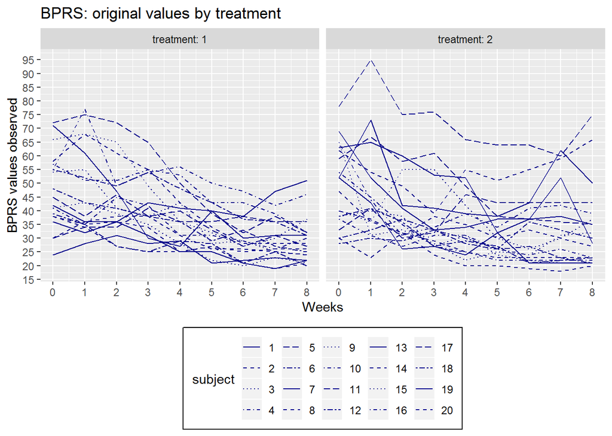

```r
ggplot(bprs_l, aes(x = week, y = BPRS, linetype = subject)) +
  geom_line(color = "darkblue") +
  scale_linetype_manual(values = rep(1:6, times = 4)) +
  facet_grid(. ~ treatment, labeller = label_both) +
  scale_x_continuous(name = "Weeks", breaks = seq(0,8,1)) +
  scale_y_continuous(name = "BPRS values observed", breaks = seq(10,100,5)) +
  theme(legend.position = "bottom") +
  ggtitle("BPRS: original values by treatment") +
  theme(legend.box.background = element_rect(),legend.box.margin = margin(2, 2, 2, 2))
```

Add fitted BPRS values created by the random intercept and random slope model with interaction ‘time * treatment’ to the dataset

```r
bprs_l_fit <- fitted(bprs_l_rim2)
bprs_l$fitted_bprs <- round(bprs_l_fit, digits = 2)
bprs_l %>% knitr::kable() %>% kable_styling(bootstrap_options = "striped", full_width = FALSE, position = "center") %>% scroll_box(height = "300px")
```

| treatment | subject | weeks | BPRS | week | fitted_bprs |
| --- | --- | --- | --- | --- | --- |
| 1 | 1 | week0 | 42 | 0 | 49.24 |
| 1 | 2 | week0 | 58 | 0 | 46.97 |
| 1 | 3 | week0 | 54 | 0 | 47.66 |
| 1 | 4 | week0 | 55 | 0 | 49.85 |
| 1 | 5 | week0 | 72 | 0 | 66.39 |
| 1 | 6 | week0 | 48 | 0 | 42.59 |
| 1 | 7 | week0 | 71 | 0 | 54.58 |
| 1 | 8 | week0 | 30 | 0 | 47.93 |
| 1 | 9 | week0 | 41 | 0 | 42.08 |
| 1 | 10 | week0 | 57 | 0 | 53.35 |
| 1 | 11 | week0 | 30 | 0 | 59.97 |
| 1 | 12 | week0 | 55 | 0 | 48.42 |
| 1 | 13 | week0 | 36 | 0 | 50.36 |
| 1 | 14 | week0 | 38 | 0 | 40.93 |
| 1 | 15 | week0 | 66 | 0 | 55.07 |
| 1 | 16 | week0 | 41 | 0 | 44.43 |
| 1 | 17 | week0 | 45 | 0 | 43.93 |
| 1 | 18 | week0 | 39 | 0 | 36.82 |
| 1 | 19 | week0 | 24 | 0 | 38.14 |
| 1 | 20 | week0 | 38 | 0 | 39.01 |
| 2 | 1 | week0 | 52 | 0 | 46.95 |
| 2 | 2 | week0 | 30 | 0 | 44.68 |
| 2 | 3 | week0 | 65 | 0 | 45.36 |
| 2 | 4 | week0 | 37 | 0 | 47.56 |
| 2 | 5 | week0 | 59 | 0 | 64.10 |
| 2 | 6 | week0 | 30 | 0 | 40.30 |
| 2 | 7 | week0 | 69 | 0 | 52.29 |
| 2 | 8 | week0 | 62 | 0 | 45.64 |
| 2 | 9 | week0 | 38 | 0 | 39.79 |
| 2 | 10 | week0 | 65 | 0 | 51.05 |

[output cut: 330 more lines]

Draw the plot with the fitted BPRS values

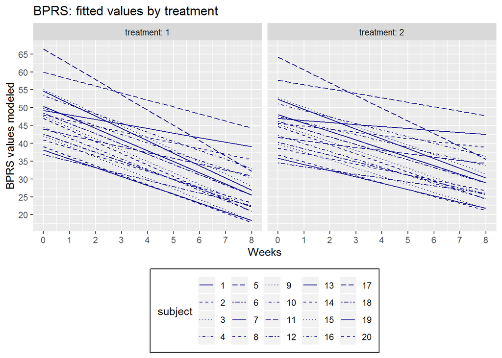

```r
ggplot(bprs_l, aes(x = week, y = fitted_bprs, linetype = subject)) +
  geom_line(color = "darkblue") +
  scale_linetype_manual(values = rep(1:6, times = 4)) +
  facet_grid(. ~ treatment, labeller = label_both) +
  scale_x_continuous(name = "Weeks", breaks = seq(0,8,1)) +
  scale_y_continuous(name = "BPRS values modeled", breaks = seq(10,100,5)) +
  theme(legend.position = "bottom") +
  ggtitle("BPRS: fitted values by treatment") +
  theme(legend.box.background = element_rect(),legend.box.margin = margin(2, 2, 2, 2))
```